# Math 421 - Midterm

## Instruction

The midterm has two components: the Rmarkdown notebook (html) and the presentation. We will do the presentation in class. Post both the notebook and the presentation on your Github page.

**The notebook:** The notebook should be created using `rmarkdown` (like other assignments). The notebook should have a title. It should have a table of content (TOC form) or in a tab form. The Rmd files of Tab and Toc form are available on the class webpage.

**The Presentation:** Present your results in 5-10 minutes. To make the presentation using Rmarkdown, do the follows:

```
- In Rstudio -> File -> New File -> R markdown

- In the left panel, click to Presentation -> Click OK

- Now you have an Rmarkdown that can be knitted to be a html presentation
```

- You can also use Rmd samples of the class slides that are available on the class webpage.
- You do not need to rerun all the codes for the presentation. For example, to show the model comparison, you just need to show the image of the model comparison instead of running all the models again.
- To inset an image in a slide, use `![](image.png)`
- To scale images, you can follow these below instructions.
  - https://bookdown.org/yihui/rmarkdown-cookbook/figure-size.html
  - http://zevross.com/blog/2017/06/19/tips-and-tricks-for-working-with-images-and-figures-in-r-markdown-documents/
- To turn off message and warning of a code cell, use: `{r, message=FALSE, warning=FALSE}` for the cell.

**What to present**:

- Present Part 2 - Visualization
- Present Question Question 4, 5 and 6 in Part 3.
- Present any errors/challenges you run into and how you fix/overcome them.

**Data:**

The data for the mid-term project is the Rhode Island Department of Health Hospital Discharge Data. Each row of the data presents a patient.

Link: https://drive.google.com/open?id=15QNBf6YYKocK2nNIfpKDer58kQnCPNZJ

## I. Data Wranggling

1. Download the data file `hdd0318cy.sas7bdat`.
2. Use `read_sas` in library `haven` to read the data.

```r
library(haven)
setwd("C:\\Users\\student\\Desktop")
df <- read_sas("hdd0318cy.sas7bdat")
setwd("C:/Users/student/Desktop/R Math421/rwalsh11.github.io/")
```

3. Filter the data to have only patients of the year 2018 (`yod=2018`)

```r
library(tidyverse)
df1 <- df %>% filter(yod=='18')
```

4. Select to work with only following variables:

```r
library(dplyr)
df1 <- df1 %>% select("yod", "payfix","pay_ub92","age",
                      "sex","raceethn","provider","moa",
                      "yoa","mod","admtype", "asource" ,
                      "preopday" ,"los", "service" , "icu","ccu",
                      "dispub92", "payer"  ,"drg","trandb",
                      "randbg","randbs","orr", "anes","seq",
                      "lab","dtest", "ther","blood","phar",
                      "other","patcon","bwght","total","tot" ,
                      "ecodub92","b_wt","pt_state","diag_adm","ancilar" ,
                      "campus","er_fee","er_chrg","er_mode","obs_chrg",
                      "obs_hour","psycchrg","nicu_day")
library(tidyverse)
write_csv(df1, 'midterm.csv')
```

*Notice*: You may want to save the current data to your computer for easy access later. To save the data file use `write_csv(df, 'midterm.csv')`, for example.

5. What are variables that have missing values?

```r
library(tidyverse)
df1 <- read_csv("midterm.csv")
colSums(is.na(df1))
```

```
##      yod   payfix pay_ub92      age      sex raceethn provider      moa
##        0   131478        0        0        0     3950        0        0
##      yoa      mod  admtype  asource preopday      los  service      icu
##        0        0        1        6    60486        0        0        0
##      ccu dispub92    payer      drg   trandb   randbg   randbs      orr
##        0        0        0        0        0        0        0        0
##     anes      seq      lab    dtest     ther    blood     phar    other
##        0        0        0        0        0        0        0        0
##   patcon    bwght    total      tot ecodub92     b_wt pt_state diag_adm
##        0   131478        0        0   104339        0        3       50
##  ancilar   campus   er_fee  er_chrg  er_mode obs_chrg obs_hour psycchrg
##        0        0        0        0    12158        0    77343        0
## nicu_day
##   124090
```

6. Remove all variables with missing values.

```r
df1 %>% select(-nicu_day,-er_mode,-obs_chrg,-ecodub92,-payfix)
```

```
## # A tibble: 131,478 × 44
##      yod pay_ub92   age   sex raceethn provi…¹   moa   yoa   mod admtype asource
##    <dbl>    <dbl> <dbl> <dbl>    <dbl>   <dbl> <dbl> <dbl> <dbl>   <dbl> <chr>
##  1    18        9     0     1        1    7214     1    18     1       4 S
##  2    18        2    76     2        1    7214     1    18     1       3 1
##  3    18        6    50     2        1    7214    12    17     1       2 1
##  4    18        4     0     1        7    7214     1    18     1       4 S
##  5    18       13     0     1        1    7214    12    17     1       4 S
##  6    18        4     0     2        9    7214    12    17     1       4 T
##  7    18        4     0     2        1    7214     1    18     1       4 S
##  8    18       13     0     2        1    7214     1    18     1       4 S
##  9    18        1    70     2        1    7214     1    18     1       2 1
## 10    18        9    25     2        1    7214    12    17     1       2 1
## # … with 131,468 more rows, 33 more variables: preopday <dbl>, los <dbl>,
## #   service <chr>, icu <chr>, ccu <chr>, dispub92 <chr>, payer <chr>,
## #   drg <dbl>, trandb <chr>, randbg <chr>, randbs <chr>, orr <chr>, anes <chr>,
## #   seq <chr>, lab <chr>, dtest <chr>, ther <chr>, blood <chr>, phar <chr>,
## #   other <chr>, patcon <chr>, bwght <lgl>, total <chr>, tot <dbl>, b_wt <chr>,
## #   pt_state <chr>, diag_adm <chr>, ancilar <chr>, campus <dbl>, er_fee <chr>,
## #   er_chrg <chr>, obs_hour <dbl>, psycchrg <chr>, and abbreviated variable …
```

7. Refer to the data description in the file `HDD2015-18cy6-20-19.docx`, which variable recording the month of admission?, which variable recording the month of discharge?

```r
table(df1$moa)
```

```
##
##     1     2     3     4     5     6     7     8     9    10    11    12
## 11309 10259 11073 11174 11404 10690 10962 11199 10666 11408 10636 10698
```

```r
table(df1$mod)
```

```
##
##     1     2     3     4     5     6     7     8     9    10    11    12
## 11199 10248 11164 11049 11419 10892 10725 11307 10622 11384 10669 10800
```

```r
#neither of these work(having major trouble viewing data)
```

8. Which month admitted the most number of patients? Which month admitted the most number of male patients?

```r
df1 %>% arrange(-tot) %>% filter(sex == 1)
```

```
## # A tibble: 58,799 × 49
##      yod payfix pay_ub92   age   sex raceethn provider   moa   yoa   mod admtype
##    <dbl> <lgl>     <dbl> <dbl> <dbl>    <dbl>    <dbl> <dbl> <dbl> <dbl>   <dbl>
##  1    18 NA            4    26     1        1     7205     8    17     5       5
##  2    18 NA            4    34     1        1     7205     6    17     6       2
##  3    18 NA            6    14     1        1     7215     9    16     2       3
##  4    18 NA            6     0     1        1     7214     4    18    10       4
##  5    18 NA            3     0     1        1     7214    10    17     3       4
##  6    18 NA            1    73     1        1     7205     3    18     4       2
##  7    18 NA            3     0     1        2     7214     9    17     2       4
##  8    18 NA            3     0     1        7     7214     2    18     8       4
##  9    18 NA            4     0     1        1     7214     3    18     8       4
## 10    18 NA            6     0     1        1     7214     7    18    12       4
## # … with 58,789 more rows, and 38 more variables: asource <chr>,
## #   preopday <dbl>, los <dbl>, service <chr>, icu <chr>, ccu <chr>,
## #   dispub92 <chr>, payer <chr>, drg <dbl>, trandb <chr>, randbg <chr>,
## #   randbs <chr>, orr <chr>, anes <chr>, seq <chr>, lab <chr>, dtest <chr>,
## #   ther <chr>, blood <chr>, phar <chr>, other <chr>, patcon <chr>,
## #   bwght <lgl>, total <chr>, tot <dbl>, ecodub92 <chr>, b_wt <chr>,
## #   pt_state <chr>, diag_adm <chr>, ancilar <chr>, campus <dbl>, …
```

9. Which month has the most number of teenage female patients?

```r
df1 %>% arrange(-moa) %>% filter(sex == 2, age <= 18)
```

```
## # A tibble: 9,033 × 49
##      yod payfix pay_ub92   age   sex raceethn provider   moa   yoa   mod admtype
##    <dbl> <lgl>     <dbl> <dbl> <dbl>    <dbl>    <dbl> <dbl> <dbl> <dbl>   <dbl>
##  1    18 NA            4     0     2        9     7214    12    17     1       4
##  2    18 NA            6     0     2        3     7214    12    17     1       4
##  3    18 NA            4     0     2        1     7214    12    17     1       4
##  4    18 NA            9    17     2        1     7215    12    18    12       2
##  5    18 NA            4    12     2        7     7215    12    18    12       2
##  6    18 NA            8    13     2        2     7215    12    18    12       2
##  7    18 NA            9    16     2        1     7215    12    18    12       2
##  8    18 NA            6    11     2        2     7205    12    17     1       3
##  9    18 NA            4    17     2        2     7205    12    17     1       1
## 10    18 NA            6     0     2       NA     7210    12    18    12       4
## # … with 9,023 more rows, and 38 more variables: asource <chr>, preopday <dbl>,
## #   los <dbl>, service <chr>, icu <chr>, ccu <chr>, dispub92 <chr>,
## #   payer <chr>, drg <dbl>, trandb <chr>, randbg <chr>, randbs <chr>,
## #   orr <chr>, anes <chr>, seq <chr>, lab <chr>, dtest <chr>, ther <chr>,
## #   blood <chr>, phar <chr>, other <chr>, patcon <chr>, bwght <lgl>,
## #   total <chr>, tot <dbl>, ecodub92 <chr>, b_wt <chr>, pt_state <chr>,
## #   diag_adm <chr>, ancilar <chr>, campus <dbl>, er_fee <chr>, er_chrg <chr>, …
```

10. Which provider has the most number of female patients in October?

```r
df1 %>% group_by(sex == 2,moa ==10)
```

```
## # A tibble: 131,478 × 51
## # Groups:   sex == 2, moa == 10 [4]
##      yod payfix pay_ub92   age   sex raceethn provider   moa   yoa   mod admtype
##    <dbl> <lgl>     <dbl> <dbl> <dbl>    <dbl>    <dbl> <dbl> <dbl> <dbl>   <dbl>
##  1    18 NA            9     0     1        1     7214     1    18     1       4
##  2    18 NA            2    76     2        1     7214     1    18     1       3
##  3    18 NA            6    50     2        1     7214    12    17     1       2
##  4    18 NA            4     0     1        7     7214     1    18     1       4
##  5    18 NA           13     0     1        1     7214    12    17     1       4
##  6    18 NA            4     0     2        9     7214    12    17     1       4
##  7    18 NA            4     0     2        1     7214     1    18     1       4
##  8    18 NA           13     0     2        1     7214     1    18     1       4
##  9    18 NA            1    70     2        1     7214     1    18     1       2
## 10    18 NA            9    25     2        1     7214    12    17     1       2
## # … with 131,468 more rows, and 40 more variables: asource <chr>,
## #   preopday <dbl>, los <dbl>, service <chr>, icu <chr>, ccu <chr>,
## #   dispub92 <chr>, payer <chr>, drg <dbl>, trandb <chr>, randbg <chr>,
## #   randbs <chr>, orr <chr>, anes <chr>, seq <chr>, lab <chr>, dtest <chr>,
## #   ther <chr>, blood <chr>, phar <chr>, other <chr>, patcon <chr>,
## #   bwght <lgl>, total <chr>, tot <dbl>, ecodub92 <chr>, b_wt <chr>,
## #   pt_state <chr>, diag_adm <chr>, ancilar <chr>, campus <dbl>, …
```

11. Are female patients older than male patients, on average?

```r
d1 <- df1 %>% group_by(sex == 1) %>% summarise(mean = mean(age))
d2 <- df1 %>% group_by(sex == 2) %>% summarise(mean = mean(age))
d1
```

```
## # A tibble: 2 × 2
##   `sex == 1`  mean
##   <lgl>      <dbl>
## 1 FALSE       50.9
## 2 TRUE        51.5
```

```r
d2
```

```
## # A tibble: 2 × 2
##   `sex == 2`  mean
##   <lgl>      <dbl>
## 1 FALSE       51.5
## 2 TRUE        50.9
```

12. Calculate the average age of patients by months. Which month has the oldest patients on average age?

```r
d3 <- df1 %>% group_by(moa) %>% summarise(mean = mean(age))
d3
```

```
## # A tibble: 12 × 2
##      moa  mean
##    <dbl> <dbl>
##  1     1  51.8
##  2     2  51.2
##  3     3  51.1
##  4     4  51.4
##  5     5  50.6
##  6     6  51.5
##  7     7  51.3
##  8     8  50.9
##  9     9  50.6
## 10    10  50.8
## 11    11  51.0
## 12    12  51.5
```

13. What is the name of the provider that has the highest total charge?

```r
d4 <- df1 %>% group_by(provider)
head(d4, n = 10)
```

```
## # A tibble: 10 × 49
## # Groups:   provider [1]
##      yod payfix pay_ub92   age   sex raceethn provider   moa   yoa   mod admtype
##    <dbl> <lgl>     <dbl> <dbl> <dbl>    <dbl>    <dbl> <dbl> <dbl> <dbl>   <dbl>
##  1    18 NA            9     0     1        1     7214     1    18     1       4
##  2    18 NA            2    76     2        1     7214     1    18     1       3
##  3    18 NA            6    50     2        1     7214    12    17     1       2
##  4    18 NA            4     0     1        7     7214     1    18     1       4
##  5    18 NA           13     0     1        1     7214    12    17     1       4
##  6    18 NA            4     0     2        9     7214    12    17     1       4
##  7    18 NA            4     0     2        1     7214     1    18     1       4
##  8    18 NA           13     0     2        1     7214     1    18     1       4
##  9    18 NA            1    70     2        1     7214     1    18     1       2
## 10    18 NA            9    25     2        1     7214    12    17     1       2
## # … with 38 more variables: asource <chr>, preopday <dbl>, los <dbl>,
## #   service <chr>, icu <chr>, ccu <chr>, dispub92 <chr>, payer <chr>,
## #   drg <dbl>, trandb <chr>, randbg <chr>, randbs <chr>, orr <chr>, anes <chr>,
## #   seq <chr>, lab <chr>, dtest <chr>, ther <chr>, blood <chr>, phar <chr>,
## #   other <chr>, patcon <chr>, bwght <lgl>, total <chr>, tot <dbl>,
## #   ecodub92 <chr>, b_wt <chr>, pt_state <chr>, diag_adm <chr>, ancilar <chr>,
## #   campus <dbl>, er_fee <chr>, er_chrg <chr>, er_mode <dbl>, obs_chrg <chr>, …
```

14. What is the name of the provider that has the least total charge for teenage male on average?

```r
df1$trandb <- as.numeric(df1$trandb)
df1 %>% filter(sex == 1) %>%  group_by(provider) %>% summarise(mean = mean(trandb))
```

```
## # A tibble: 12 × 2
##    provider   mean
##       <dbl>  <dbl>
##  1     7201  9768.
##  2     7202 19231.
##  3     7204 12566.
##  4     7205 22108.
##  5     7206 11460.
##  6     7209  7663.
##  7     7210 12466.
##  8     7211  8930.
##  9     7213 11890.
## 10     7214 21336.
## 11     7215 81930.
## 12     7216 14865.
```

15. Create a season (Spring, Summer, Fall, Winter) variable. Calculate the length of stays by season. Which season has the longest length of stays on average?

```r
df1$season <- case_when(df1$moa %in% c("3","4","5") ~ 'spring',
                       df1$moa %in% c("6","7","8") ~ 'summer', df1$moa %in% c("9","10","11") ~ 'fall', df1$moa %in% c("12","1","2") ~ 'winter')

df1 %>% group_by(season) %>% summarise(mean = mean(los))
```

```
## # A tibble: 4 × 2
##   season  mean
##   <chr>  <dbl>
## 1 fall    4.96
## 2 spring  4.84
## 3 summer  4.96
## 4 winter  4.93
```

16. On average, how much a 20 year-old male get charged for staying 1 day in the Fall season?

```r
df1 %>% filter(sex == 1, los == 1, age == 20, season == "fall")
```

```
## # A tibble: 6 × 50
##     yod payfix pay_ub92   age   sex raceethn provider   moa   yoa   mod admtype
##   <dbl> <lgl>     <dbl> <dbl> <dbl>    <dbl>    <dbl> <dbl> <dbl> <dbl>   <dbl>
## 1    18 NA            8    20     1        1     7210    10    18    10       1
## 2    18 NA            6    20     1        1     7204    10    18    10       1
## 3    18 NA            3    20     1        1     7205    10    18    10       1
## 4    18 NA            8    20     1        1     7205    11    18    11       1
## 5    18 NA            6    20     1        1     7213    11    18    11       1
## 6    18 NA            3    20     1        1     7201    11    18    11       1
## # … with 39 more variables: asource <chr>, preopday <dbl>, los <dbl>,
## #   service <chr>, icu <chr>, ccu <chr>, dispub92 <chr>, payer <chr>,
## #   drg <dbl>, trandb <dbl>, randbg <chr>, randbs <chr>, orr <chr>, anes <chr>,
## #   seq <chr>, lab <chr>, dtest <chr>, ther <chr>, blood <chr>, phar <chr>,
## #   other <chr>, patcon <chr>, bwght <lgl>, total <chr>, tot <dbl>,
## #   ecodub92 <chr>, b_wt <chr>, pt_state <chr>, diag_adm <chr>, ancilar <chr>,
## #   campus <dbl>, er_fee <chr>, er_chrg <chr>, er_mode <dbl>, obs_chrg <chr>, …
```

17. Write a paragraph to summarize the section and give your comments on the results. You could do some other calculations to support your points.

## II. Data Visualization

Continue with the data from part I.

1. Provides at least 10 meaningful plots. Comments on the plots. All plots should have title, caption, appropriate labels on x and y-axis

```r
df1 %>% ggplot(aes(x = moa,
           y = tot, color=sex))+
  geom_point()
  labs(title = 'moa: {closest_state}')
```

[output not shown]

2. Make an animation plot.

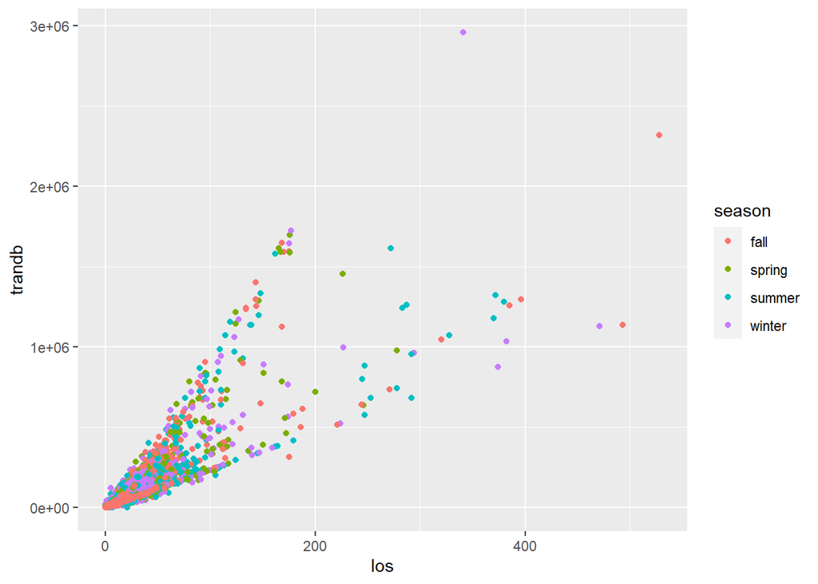

```r
library(gganimate)
library(ggplot2)
library(tidyverse)
library(lubridate)
plot1 <- df1 %>% filter(season %in% c('fall','summer','spring','winter')) %>%
  ggplot(aes(y=trandb,
            x=los,
            color=season))+
  geom_point()
plot1
```

3. Write a paragraph to summarize the section and give your comments on the results.

## III. Predictive Models

Continue with the data from part I. Make sure you do not have any missing values in the data. Use the follows as the target and input variables:

```r
df1 %>%
  summarise(median(tot))
```

```
## # A tibble: 1 × 1
##   `median(tot)`
##           <dbl>
## 1         21854
```

```r
library(tidyverse)
library(dplyr)
df1$tot <- case_when(
  df1$tot <16228     ~ 'low',
  TRUE ~ 'high'
)
df1 <- df1 %>% rename(target=tot)

df1 <- df1 %>%
  mutate(target = as.factor(target),)
df2 <- df1 %>% select(age,sex,raceethn,provider,moa,mod,admtype,campus, los,target)
```

- `high` otherwise.

*Input Variables*:

- “age”,“sex”,“raceethn”,“provider”,“moa”,“mod”,“admtype”,“campus”, ‘los’

```r
df2 <- df1 %>% select(age,sex,raceethn,provider,moa,mod,admtype,campus, los,target)
```

1. Use `filter` function to filter out rows where `raceethn==''` or `raceethn==''`. Make sure all the categorical variables are factor, numeric variables are numeric. Set Training : Testing Split = 10 : 90

```r
library(caret)
set.seed(2020)
unique(df2$raceethn)
```

```
## [1]  1  7  9  3  2 NA  6  4
```

```r
df2 %>% mutate(-is.na(raceethn))
```

```
## # A tibble: 131,478 × 11
##      age   sex raceethn provider   moa   mod admtype campus   los target -is.n…¹
##    <dbl> <dbl>    <dbl>    <dbl> <dbl> <dbl>   <dbl>  <dbl> <dbl> <fct>    <int>
##  1     0     1        1     7214     1     1       4      0     2 low          0
##  2    76     2        1     7214     1     1       3      0     1 high         0
##  3    50     2        1     7214    12     1       2      0     3 high         0
##  4     0     1        7     7214     1     1       4      0     4 low          0
##  5     0     1        1     7214    12     1       4      0    35 high         0
##  6     0     2        9     7214    12     1       4      0    17 high         0
##  7     0     2        1     7214     1     1       4      0     2 low          0
##  8     0     2        1     7214     1     1       4      0     3 low          0
##  9    70     2        1     7214     1     1       2      0     2 high         0
## 10    25     2        1     7214    12     1       2      0    12 high         0
## # … with 131,468 more rows, and abbreviated variable name ¹`-is.na(raceethn)`
```

```r
splitIndex <- createDataPartition(df2$target, p = .10,
                                  list = FALSE)
df_train <- df2[ splitIndex,]
df_test <- df2[-splitIndex,]
```

2. Train a decision tree using `rpart`. Plot the decision tree. Plot the variable importance ranked by the tree.

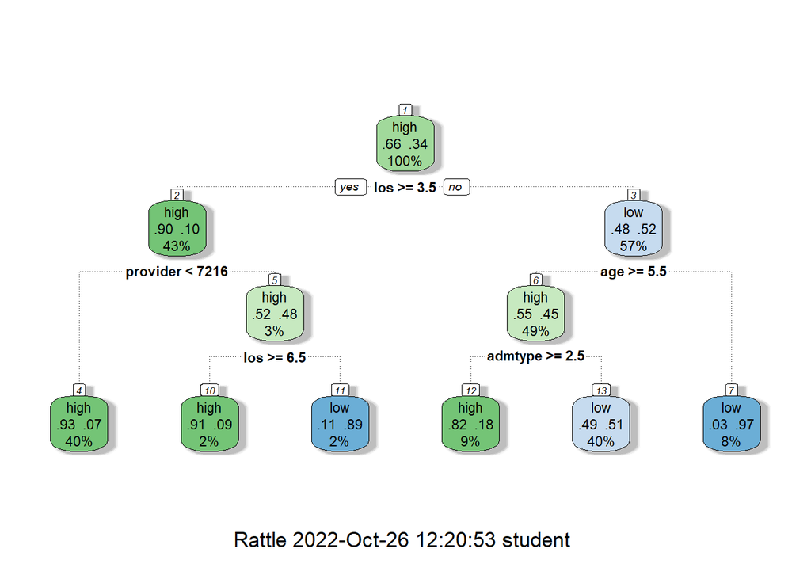

```r
library(rpart)
tree_model <- rpart(target ~ ., data = df_train,
                 control = rpart.control(maxdepth = 3))
library(rattle)
fancyRpartPlot(tree_model)
```

```r
tree_model$variable.importance
```

```
##         los     admtype         age    provider      campus         moa
## 1275.529248  633.959342  519.639496  190.814758   43.835387    1.983575
##         mod
##    1.983575
```

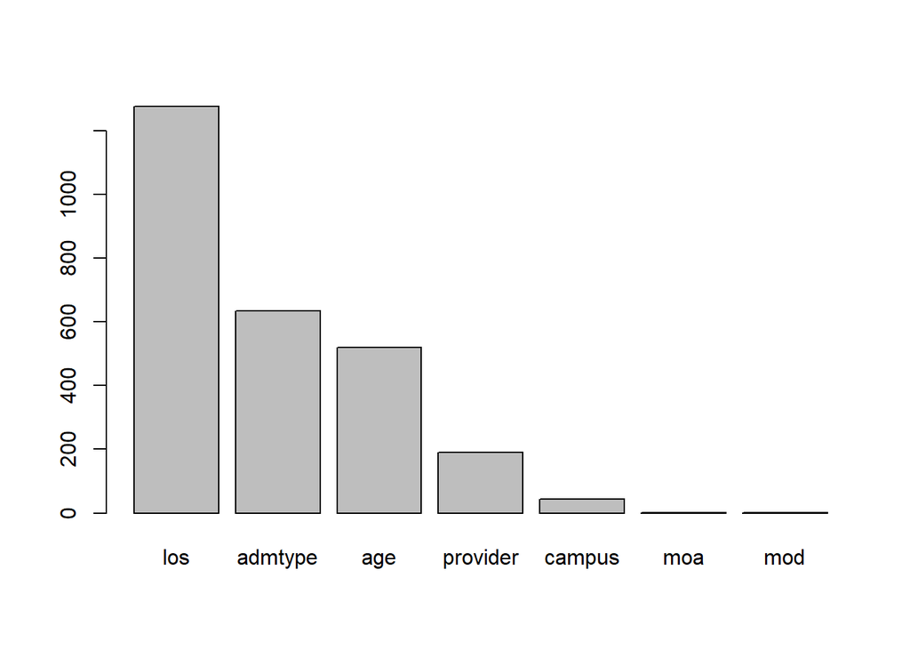

```r
barplot(tree_model$variable.importance)
```

```r
pred <- predict(tree_model, df_test, type = "class")
cm <- confusionMatrix(data = pred, reference = df_test$target)
cm$overall[1]
```

```
##  Accuracy
## 0.7591968
```

3. Using caret for this question. Set `Training Control` to be: Use Cross-Validation of 5 folds across all models. Train & tune at least 2 different models (i.e. two different values for `method=` in the train function of caret). Plot the hyper-parameter tuning plots for each model.

```r
library(caret)

tuneGrid = expand.grid(maxdepth = 2:10)

trControl = trainControl(method = "cv",
                         number = 5)

tree_approach2 <- train(target~., data=df_train,
                                method = "rpart2",
                                trControl = trControl,
                                tuneGrid = tuneGrid)
```

```r
library(caret)

tuneGrid = expand.grid(maxdepth = 2:10)

trControl = trainControl(method = "cv",
                         number = 5)

tree_approach3 <- train(target~., data=df_train,
                                method = "rf",
                                trControl = trControl,
                                tuneGrid = tuneGrid)
```

4. Plot the comparison of the models in 3.

```r
plot(tree_approach2)
print(tree_approach2)
pred <- predict(tree_approach2, df_test)
cm0 <- confusionMatrix(data = pred, reference = df_test$target)
cm0$overall[1]
```

[output not shown]

```r
plot(tree_approach3)
print(tree_approach3)
pred <- predict(tree_approach3, df_test)
cm1 <- confusionMatrix(data = pred, reference = df_test$target)
cm1$overall[1]
```

[output not shown]

5. What is your final selection for the model? Test the accuracy of your final model on the test data.
6. Create another `target` variable (binary), decide the input variables and redo 1 to 5.

```r
df1 <- df1 %>% rename(target=los)#new target(have not established anything else)

df1 <- df1 %>%
  mutate(target = as.factor(target),)
df2 <- df1 %>% select(age,sex,raceethn,provider,moa,mod,admtype,campus, los,target)
library(caret)
set.seed(2020)
df2 <- (df2 %>%  select(raceethn) %>% filter(-raceethn=='') )
splitIndex <- createDataPartition(df2$target, p = .10,
                                  list = FALSE)
df_train <- df2[ splitIndex,]
df_test <- df2[-splitIndex,]

tuneGrid = expand.grid(maxdepth = 2:10)

trControl = trainControl(method = "cv",
                         number = 5)

tree_approach2 <- train(target~., data=df_train,
                                method = "rpart2",
                                trControl = trControl,
                                tuneGrid = tuneGrid)
```

7. Write a paragraph to summarize the section and give your comments on the results.